# Museums and Nature Centers

Md. Tabassum Hossain Emon [^1]

6/21/2020

There are thousands of museums, aquariums, and zoos across the United States. This project focuses on visualizing the distribution of these institutions by geographic region, type, and revenue.

[figure not shown]

Institute of Museum and Library Services

This data compiled from administrative records from the [Institute of Museum and Library Services](https://www.imls.gov/), [IRS records](https://www.irs.gov/), and private foundation grantmaking records. This data reflects the status of each institution as of 2013. For each institution, here is information on its name, type, and location. Each institution also has a parent organization – for example, if a museum housed at a university, its parent organization is the university where it resides. Financial data on annual revenue is available at the parent organization level.

```r
library(dplyr)
library(ggplot2)
library(stringr)
library(tidyr)
library(plotrix)
library(knitr)
```

# *Data Exploration*

The `Museum.Name` column represents the name of each individual institution, while the `Legal.Name` column represents the name of each institution’s parent entity.

```r
# Loading file as data frame
museums_df <- read.csv("museums.csv")
```

```r
# Inspecting data frame
head(museums_df) %>% kable()
```

| Museum.Name | Legal.Name | Museum.Type | State..Administrative.Location. | Region.Code..AAM. | Is.Museum | Tax.Year | Annual.Revenue |
| --- | --- | --- | --- | --- | --- | --- | --- |
| ALASKA AVIATION HERITAGE MUSEUM | ALASKA AVIATION HERITAGE MUSEUM | HISTORY MUSEUM | AK | 6 | TRUE | 2013 | 1100472 |
| ALASKA BOTANICAL GARDEN | ALASKA BOTANICAL GARDEN INC | ARBORETUM, BOTANICAL GARDEN, OR NATURE CENTER | AK | 6 | FALSE | 2013 | 1323742 |
| ALASKA CHALLENGER CENTER FOR SPACE SCIENCE TECHNOLOGY | ALASKA CHALLENGER CENTER FOR SPACE SCIENCE TECHNOLOGY INC | SCIENCE & TECHNOLOGY MUSEUM OR PLANETARIUM | AK | 6 | TRUE | 2013 | 729080 |
| ALASKA HERITAGE MUSEUM | ALASKA AVIATION HERITAGE MUSEUM | HISTORY MUSEUM | AK | 6 | TRUE | 2013 | 1100472 |
| ALASKA JEWISH MUSEUM | ALASKA JEWISH HISTORICAL MUSEUM AND CULTURAL CENTER | GENERAL MUSEUM | AK | 6 | TRUE | 2013 | 68748 |
| ALASKA LIGHTHOUSE ASSOCIATION | ALASKA LIGHTHOUSE ASSOCIATION | HISTORIC PRESERVATION | AK | 6 | FALSE | 2013 | 16500 |

## Museums by Type

This data frame contains a column called `Museum.Type` describing what kind of museum each location is – a history museum, a zoo, an aquarium, etc.

*Here I’ve created frequency barplot and tried to answer, which category is most common?*

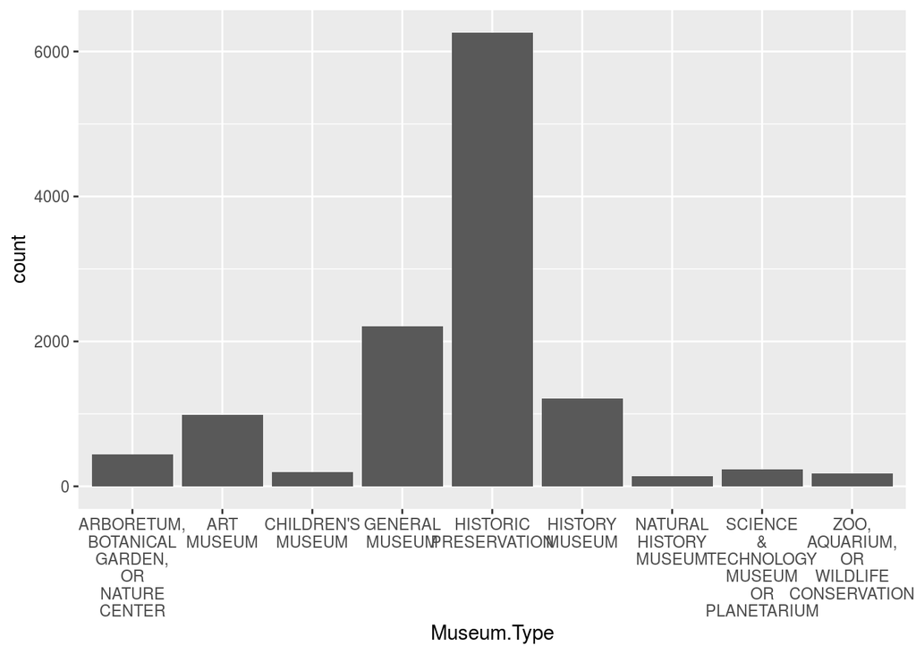

```r
# Creating and printing bar plot by type
museum_type <- ggplot(museums_df, aes(x = Museum.Type)) + geom_bar() + scale_x_discrete(labels = scales::wrap_format(8))
museum_type
```

## Museum Or Not

In the data frame there is a boolean (TRUE or FALSE) column, called Is.Museum. The `TRUE` category includes typical museums like art, history, and science museums. The `FALSE` category includes zoos, aquariums, nature preserves, and historic sites, which are included in this data but aren’t what most people think of when they hear the word “museum.”

Here in the barplot that is classified.

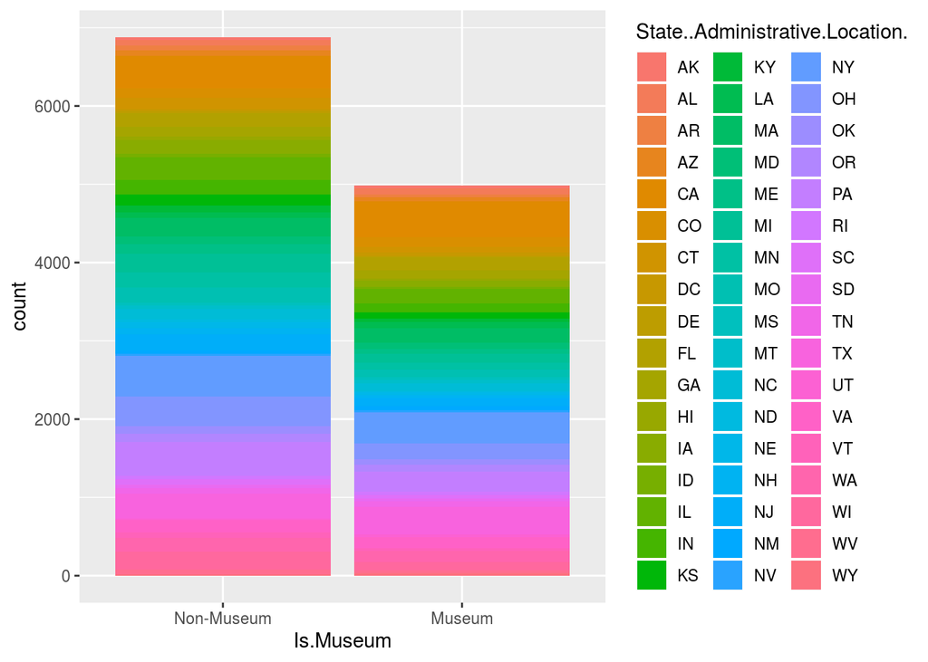

```r
# Creating and printing bar plot by museum vs non-museum
museum_class <- ggplot(museums_df, aes(x= Is.Museum,fill = State..Administrative.Location.)) +
geom_bar() +
scale_x_discrete(
  labels = c(
    "TRUE" = "Museum",
    "FALSE" = "Non-Museum"
    )
    )
museum_class
```

## Classifying by State

Instead of looking at the distribution across the entire *United States*, just few states can be represented.

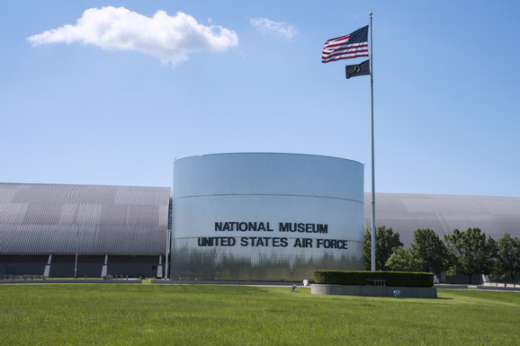

USA_Museums

for example, I’ve chosen *IL*, *CA*, and *NY*.

```r
# Filtering data frame to select states
museums_states <- museums_df %>%
 filter(State..Administrative.Location. %in% c( "IL","CA","NY"))

head(museums_states) %>% kable()
```

| Museum.Name | Legal.Name | Museum.Type | State..Administrative.Location. | Region.Code..AAM. | Is.Museum | Tax.Year | Annual.Revenue |
| --- | --- | --- | --- | --- | --- | --- | --- |
| 1078 GALLERY | 1078 GALLERY INC | ART MUSEUM | CA | 6 | TRUE | 2013 | 42031 |
| 18TH STREET ARTS COMPLEX | 18TH STREET ARTS COMPLEX | ART MUSEUM | CA | 6 | TRUE | 2013 | 755147 |
| ACADEMY INTERACTIVE ARTS SCIENCES | ACADEMY OF INTERACTIVE ARTS AND SCIENCES | ART MUSEUM | CA | 6 | TRUE | 2013 | 1826158 |
| AEROSPACE MUSEUM OF CALIFORNIA FOUNDATION | AEROSPACE MUSEUM OF CALIFORNIA FOUNDATION | GENERAL MUSEUM | CA | 6 | TRUE | 2013 | 896891 |
| AFRICAN AMERICAN ART AND CULTURE | THE AFRICAN AMERICAN ART AND CULTURE COMPLEX | ART MUSEUM | CA | 6 | TRUE | 2013 | 914111 |
| AFRICAN AMERICAN FIREFIGHTER MUSEUM | AFRICAN AMERICAN FIREFIGHTER MUSEUM | GENERAL MUSEUM | CA | 6 | TRUE | 2013 | 53379 |

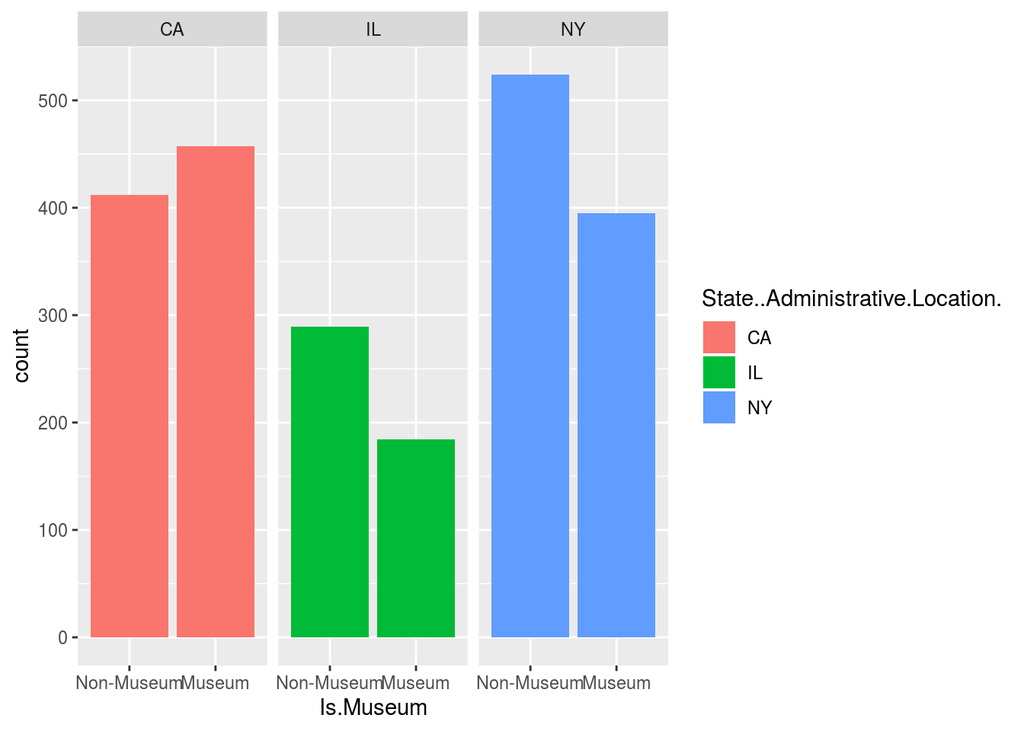

```r
# Creating and printing bar plot with facets
museum_facet <- ggplot(museums_states, aes(x= Is.Museum, fill = State..Administrative.Location.)) +
geom_bar() +
scale_x_discrete(
  labels = c(
    "TRUE" = "Museum",
    "FALSE" = "Non-Museum"
    )
    ) +
    facet_grid(cols = vars(State..Administrative.Location.))

museum_facet
```

This data also contains information on each museum’s region, representing groups of states.

And tried to answer, *How does the distribution of museum types vary by region?*

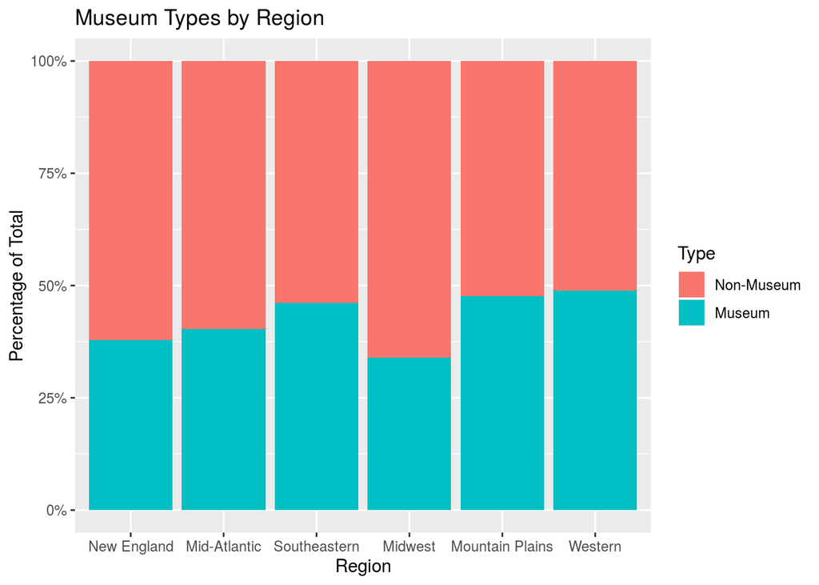

```r
# Creating and printing stacked bar plot
museums_stack <- ggplot(museums_df, aes(x = factor(Region.Code..AAM.), fill = Is.Museum)) +
  geom_bar(position = "fill") +
  scale_x_discrete(labels = c(
    "1" = "New England",
    "2" = "Mid-Atlantic",
    "3" = "Southeastern",
    "4" = "Midwest",
    "5" = "Mountain Plains",
    "6" = "Western"
  )) +
  scale_fill_discrete(labels = c(
    "TRUE" = "Museum",
    "FALSE" = "Non-Museum"
  )) + scale_y_continuous (labels = scales::percent_format()) +
  labs(title = "Museum Types by Region", x = "Region", y = "Percentage of Total", fill = "Type")

museums_stack
```

# *Exploring Museums by Revenue*

Now lets switch to look at *how much money each institution brought in* and *how that varies across geographies*. Because here are only revenue data at the parent organization level,lets first filter the dataset to omit any duplicates. Next, i’ve created a few data frames from the starting data to look at different groups of museums by *how much money they bring in*.

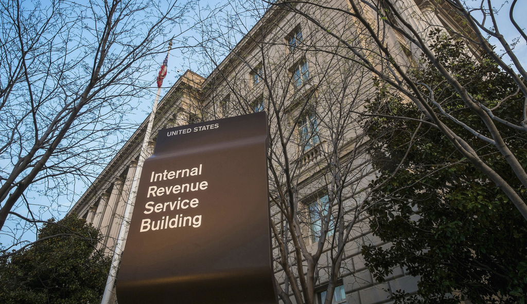

IRS

`museums_small_df` that retains only museums with `Annual.Revenue` less than $1,000,000.

And `museums_large_df` that retains only museums with `Annual.Revenue` greater than $1,000,000,000.

```r
# Filtering data frame
museums_revenue_df <- museums_df %>%
  distinct(Legal.Name, .keep_all = TRUE) %>%
   filter(Annual.Revenue>0)

# Filtering for only small museums
museums_small_df <- museums_revenue_df %>%
   filter(Annual.Revenue<1000000)

# Filtering for only large museums
museums_large_df <- museums_revenue_df %>%
   filter(Annual.Revenue > 1000000000)
```

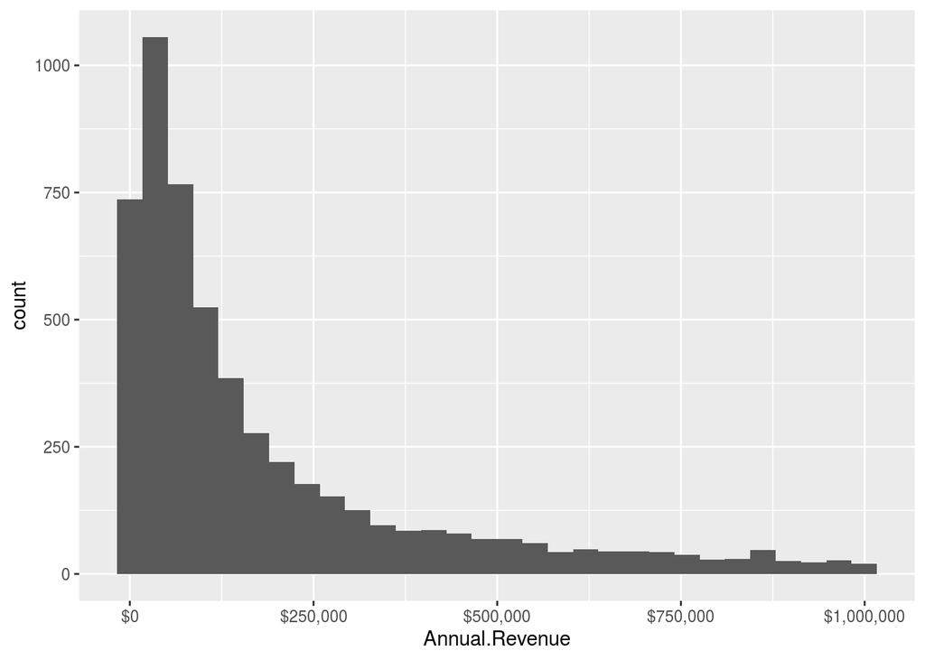

```r
# Creating and printing histogram
revenue_histogram <- ggplot(museums_small_df, aes(x = Annual.Revenue)) +
  geom_histogram() +
  scale_x_continuous(labels = scales::dollar_format())

revenue_histogram
```

Now, let’s look at the *variation in revenue* for large museums by region.

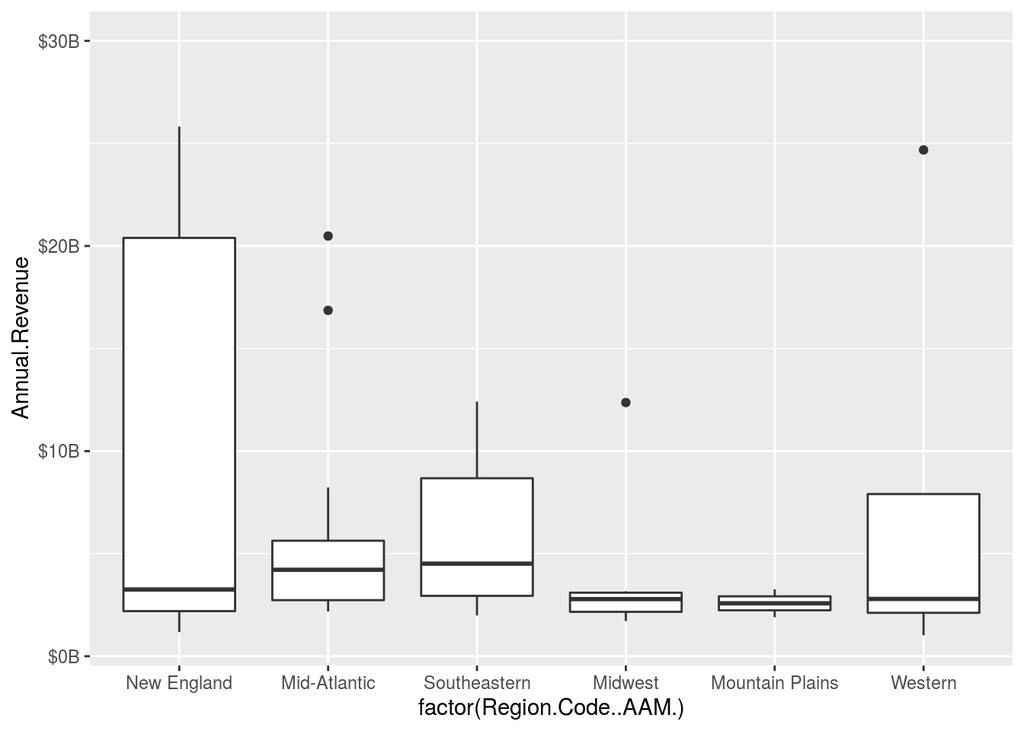

```r
# Creating and printing boxplot

revenue_boxplot <- ggplot(museums_large_df, aes(x = factor(Region.Code..AAM.), y = Annual.Revenue)) +
  geom_boxplot() +
  scale_x_discrete(labels = c(
    "1" = "New England",
    "2" = "Mid-Atlantic",
    "3" = "Southeastern",
    "4" = "Midwest",
    "5" = "Mountain Plains",
    "6" = "Western"
  )
  ) +
  coord_cartesian(ylim = c(1e9, 3e10)) +
  scale_y_continuous(labels = function(x) paste0("$", x/1e9, "B") )



revenue_boxplot
```

## Revenue Across All Museums

Now, let’s take a look at revenue across all museums in the dataset.

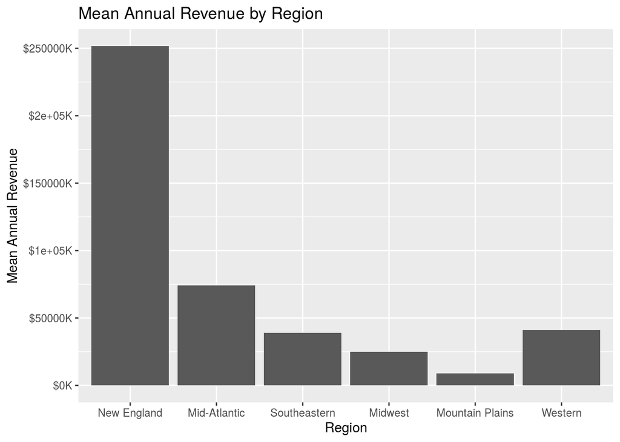

```r
# Creating and printing bar plot with means
revenue_barplot <- ggplot(museums_revenue_df, aes(x = factor(Region.Code..AAM.), y = Annual.Revenue)) +
  geom_bar(stat ="summary", fun = "mean") +
  labs(title = "Mean Annual Revenue by Region", x = "Region", y = "Mean Annual Revenue") +
  scale_x_discrete(labels = c(
    "1" = "New England",
    "2" = "Mid-Atlantic",
    "3" = "Southeastern",
    "4" = "Midwest",
    "5" = "Mountain Plains",
    "6" = "Western"
  )
  ) +
  scale_y_continuous(labels = function(x) paste0("$", x/1e3, "K"))
revenue_barplot
```

## Error Bar

Finally, let’s add some error bars to the means. Calculation of standard errors before creating the plot has been done. And tried to answer,

*Which regions have more or less variability around their mean revenues?*

```r
# Calculation of means and standard errors
museums_error_df <- museums_revenue_df %>%
  group_by(Region.Code..AAM.) %>%
  summarize(Mean.Revenue = mean(Annual.Revenue),
            Mean.SE = std.error(Annual.Revenue)) %>%
  mutate(SE.Min = Mean.Revenue - Mean.SE,
         SE.Max = Mean.Revenue + Mean.SE)

museums_error_df
```

```
## # A tibble: 6 x 5
##   Region.Code..AAM. Mean.Revenue    Mean.SE    SE.Min     SE.Max
##               <int>        <dbl>      <dbl>     <dbl>      <dbl>
## 1                 1   251642246. 185559526. 66082720. 437201772.
## 2                 2    74269995.  22290730. 51979265.  96560725.
## 3                 3    38977928.  15187644. 23790284.  54165572.
## 4                 4    24803628.   9245781. 15557847.  34049409.
## 5                 5     8896467.   4041477.  4854989.  12937944.
## 6                 6    41089182.  22894037. 18195144.  63983219.
```

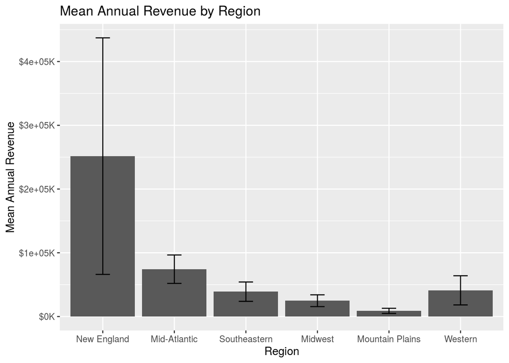

```r
# creating and printing bar plot with means and standard errors
revenue_errorbar <- ggplot(museums_error_df, aes(x = factor(Region.Code..AAM.), y = Mean.Revenue)) +
  geom_col() +
  labs(title = "Mean Annual Revenue by Region", x = "Region", y = "Mean Annual Revenue") +
  scale_x_discrete(labels = c(
    "1" = "New England",
    "2" = "Mid-Atlantic",
    "3" = "Southeastern",
    "4" = "Midwest",
    "5" = "Mountain Plains",
    "6" = "Western"
  )
  ) +
  scale_y_continuous(labels = function(x) paste0("$", x/1e3, "K")) +
  geom_errorbar (
    aes(
                ymin = SE.Min,
                ymax = SE.Max,
                width = 0.2
  )
  )



revenue_errorbar
```

[^1]: Author github: Emon-ProCoder7 2. Author Linked-in:[Md Tabassum Hossain Emon](https://www.linkedin.com/in/md-tabassum-hossain-emon-ag007/)